# PSL: Smoothing Splines

# Week 4 Example (Fall 2025)

## A Simulated Example

In this example, we are going to reproduce the example from the ESL book in section 5.5.2 in which we the true function of the data is given by

$f(x) = \frac{sin(12 (x+0.2))}{x+0.2}, \, x\in[0,1]$

So, we are first going to simulate data from this curve:

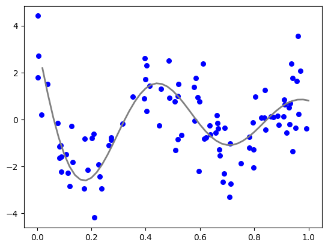

```python
import numpy as np
import matplotlib.pyplot as plt

np.random.seed(598)
n = 100

x = np.sort(np.random.uniform(0, 1, n))
y = np.sin(12 * (x + 0.2)) / (x + 0.2) + np.random.normal(0, 1, n)

plt.scatter(x, y, color="blue", s=30, marker="o")

funf_x = np.arange(1, 51) / 50
funf_y = np.sin(12 * (funf_x + 0.2)) / (funf_x + 0.2)

plt.plot(funf_x, funf_y, color="gray", linewidth=2)

plt.show()
```

### Fitting a Smoothing Spline model to the simulated data above

The function to use is `LinearGAM` and is part of the `pygam` library in `Python`.

The model is fitted as follows:

```python
from pygam import LinearGAM, s

gam = LinearGAM(s(0, n_splines=5)).fit(x, y)
gam.summary()
```

```
LinearGAM
=============================================== ==========================================================
Distribution:                        NormalDist Effective DoF:                                      2.7453
Link Function:                     IdentityLink Log Likelihood:                                  -201.7597
Number of Samples:                          100 AIC:                                              411.0101
                                                AICc:                                             411.3833
                                                GCV:                                                2.5902
                                                Scale:                                              2.4625
                                                Pseudo R-Squared:                                   0.0429
==========================================================================================================
Feature Function                  Lambda               Rank         EDoF         P > x        Sig. Code
================================= ==================== ============ ============ ============ ============
s(0)                              [0.6]                5            2.7          9.72e-08     ***
intercept                                              1            0.0          5.27e-01
==========================================================================================================
Significance codes:  0 '***' 0.001 '**' 0.01 '*' 0.05 '.' 0.1 ' ' 1

WARNING: Fitting splines and a linear function to a feature introduces a model identifiability problem
         which can cause p-values to appear significant when they are not.

WARNING: p-values calculated in this manner behave correctly for un-penalized models or models with
         known smoothing parameters, but when smoothing parameters have been estimated, the p-values
         are typically lower than they should be, meaning that the tests reject the null too readily.
```

We can compute the fitted values as follows:

```python
fitted_y = gam.predict(funf_x)
```

To illustrate the fit of the model, we can plot the fitted line on top of the data:

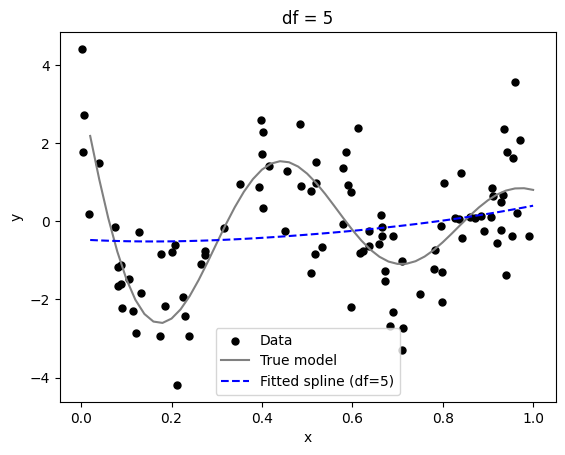

```python
plt.scatter(x, y, color="black", s=25, label="Data")

plt.plot(funf_x, funf_y, color="gray", linewidth=1.5, label="True model")

plt.plot(funf_x, fitted_y, color="blue", linestyle="--", linewidth=1.5, label="Fitted spline (df=5)")

plt.xlabel("x")
plt.ylabel("y")
plt.title("df = 5")
plt.legend()
plt.show()
```

The gray line is the true model, while the blue line is the fitted model with 5 degrees of freedom. As we discussed, if we change the degrees of freedom, e.g. df=8, then the line will be more/less sensitive to the data. For example for df=8 we have

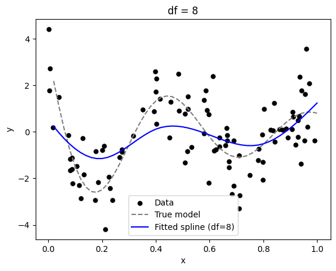

```python
gam = LinearGAM(s(0, n_splines=8)).fit(x, y)

fitted_y = gam.predict(funf_x)

plt.scatter(x, y, color="black", s=25, label="Data")

plt.plot(funf_x, funf_y, color="gray", linestyle="--", linewidth=1.5, label="True model")

plt.plot(funf_x, fitted_y, color="blue", linewidth=1.5, label="Fitted spline (df=8)")

plt.xlabel("x")
plt.ylabel("y")
plt.title("df = 8")
plt.legend()
plt.show()
```

### Choice of Lambda

The pygam package comes with an inbuilt option for smoothing parameters selection, primarily based on leave-one-out cross-validation (LOOCV) and generalized cross-validation (GCV).

```python
gam = LinearGAM(s(0, n_splines=9)).fit(x, y)

gam.summary()
```

```
LinearGAM
=============================================== ==========================================================
Distribution:                        NormalDist Effective DoF:                                      4.9457
Link Function:                     IdentityLink Log Likelihood:                                  -164.4308
Number of Samples:                          100 AIC:                                               340.753
                                                AICc:                                             341.6406
                                                GCV:                                                1.6532
                                                Scale:                                              1.5067
                                                Pseudo R-Squared:                                   0.4276
==========================================================================================================
Feature Function                  Lambda               Rank         EDoF         P > x        Sig. Code
================================= ==================== ============ ============ ============ ============
s(0)                              [0.6]                9            4.9          1.11e-16     ***
intercept                                              1            0.0          8.72e-05     ***
==========================================================================================================
Significance codes:  0 '***' 0.001 '**' 0.01 '*' 0.05 '.' 0.1 ' ' 1

WARNING: Fitting splines and a linear function to a feature introduces a model identifiability problem
         which can cause p-values to appear significant when they are not.

WARNING: p-values calculated in this manner behave correctly for un-penalized models or models with
         known smoothing parameters, but when smoothing parameters have been estimated, the p-values
         are typically lower than they should be, meaning that the tests reject the null too readily.
```

When using the `LinearGAM` function with a degree of freedom set at 9, the sum of leverages might not exactly match that number due to rounding errors.

```python
X_basis = gam._modelmat(x.reshape(-1, 1))
X = X_basis.toarray()

XtX = X.T @ X
XtX_inv = np.linalg.pinv(XtX)

H = X @ XtX_inv @ X.T

leverages = np.diag(H)
print("First 10 leverages:", leverages[:10])
print("Sum of leverages:", leverages.sum())
print("Effective df from gam:", gam.statistics_['edof'])
```

```
First 10 leverages: [0.29740108 0.27421359 0.25326119 0.15470588 0.11924724 0.11607256
 0.11027751 0.10957204 0.10288446 0.10255945]
Sum of leverages: 8.999999999999932
Effective df from gam: 4.945695733987347
```

We can compute and compare the GCV and LOOCV scores.

```python
y_hat = gam.predict(x)

rss = np.sum((y - y_hat)**2)
gcv = rss / (1 - 9/n)**2/n
print("GCV:", gcv)

cv = np.mean(((y - y_hat) / (1 - leverages))**2)
print("LOOCV:", cv)
```

```
GCV: 1.7295041396377473
LOOCV: 1.9196956702969064
```